# 05_lymphocontamination

Wenzel Hackeng

29/10/2020

## **Pre-processing**

First call the required packages

```r
library("GEOquery")
library("data.table")
library('readr')
library('randomForest')
library('glmnet')
library('pROC')
library('ModelMetrics')
library('ggplot2')
library('ggsci')
library('tidyr')
require('dplyr')
```

# function to randomly impute probes

```r
# function
# impute beta values
impute_random <- function(mat){
  stopifnot(is.matrix(mat))

  if (all(is.na(mat))) {
    warning("No non-NA data points, returning object unchanged")
    na_num <- nrow(mat)
    return(list(imputed = mat, n = na_num))
  } else {
    na_pos <- is.na(mat)
    na_num <- sum(na_pos)
    mat[na_pos] <- sample(x = mat[!na_pos], size = na_num, replace = TRUE)
    return(list(imputed = mat, n = na_num))
  }
}
```

# Download normalized GEO data for lymphocytes

Manually unzip files

```r
getGEOSuppFiles("GSE103541", makeDirectory = TRUE, baseDir =  './RAW')
```

# Preprocess GEO lymfocyte data, load model data, test-validation data

5 samples are already removed from the preprocessed GEO data due to low sample quality. These are still present in the PD file, but filtered when merging the data and PD file. The model data, test-validation data are preprocessed in 04_RandomProbeReplacement. Repeat 1, CV set 2 has perfect RF and RF+RR accuracy in the test data and the UMC data.CV Test and UMCU validation data are merged (unknown data to model)

```r
NormalizedLymphocytes<-as.data.frame(fread("./RAW/GSE103541/GSE103541_NormalisedData.csv.gz"), stringsAsFactors = FALSE)
PD_GSE103541 <- read_csv("./PD_FILES/PD_GSE103541.csv", skip = 7)
PD_GSE103541select<-PD_GSE103541[,c("normSample_Name", "Sample_Group")]

rownames(NormalizedLymphocytes)<-NormalizedLymphocytes[,1]
NormalizedLymphocytes[,1]<-NULL
tNormalizedLymphocytes<-t(NormalizedLymphocytes)

AnnotNormalizedLymphocytes<-merge(PD_GSE103541select, tNormalizedLymphocytes, by.x = "normSample_Name", by.y = "row.names")
rownames(AnnotNormalizedLymphocytes)<-AnnotNormalizedLymphocytes[,1]
AnnotNormalizedLymphocytes[,1]<-NULL
tAllLymphos<-AnnotNormalizedLymphocytes
tAllLymphos[,c("Sample_Group")]<-NULL
AllLymphos<-t(tAllLymphos)

tBcells<-subset(AnnotNormalizedLymphocytes, Sample_Group == "Bcells")
tBcells[,c("Sample_Group")]<-NULL
Bcells<-as.data.frame(t(tBcells),stringsAsFactors=FALSE)

tCD4<-subset(AnnotNormalizedLymphocytes, Sample_Group == "CD4")
tCD4[,c("Sample_Group")]<-NULL
CD4<-as.data.frame(t(tCD4),stringsAsFactors=FALSE)

tCD8<-subset(AnnotNormalizedLymphocytes, Sample_Group == "CD8")
tCD8[,c("Sample_Group")]<-NULL
CD8<-as.data.frame(t(tCD8),stringsAsFactors=FALSE)

tMonocytes<-subset(AnnotNormalizedLymphocytes, Sample_Group == "Monocytes")
tMonocytes[,c("Sample_Group")]<-NULL
Monocytes<-as.data.frame(t(tMonocytes),stringsAsFactors=FALSE)

tGranulocytes<-subset(AnnotNormalizedLymphocytes, Sample_Group == "Granulocytes")
tGranulocytes[,c("Sample_Group")]<-NULL
Granulocytes<-as.data.frame(t(tGranulocytes),stringsAsFactors=FALSE)
```

# loading normalized TCGA data (previously normalized data by preprocessIllumina)

Cases: [1] “TCGA-H6-A45N” “TCGA-H6-8124” “TCGA-FZ-5922” “TCGA-YB-A89D” “TCGA-HV-A5A3” [6] “TCGA-FZ-5920” “TCGA-FZ-5926” “TCGA-FZ-5923” “TCGA-FZ-5924” “TCGA-FZ-5919” [1] “TCGA-50-5939” “TCGA-44-2662” “TCGA-44-6144” “TCGA-44-6145” “TCGA-50-5931” [6] “TCGA-50-5930” “TCGA-50-5935” “TCGA-38-4631” “TCGA-50-6593” “TCGA-44-5645”

```r
tcganormal_metadata <- readRDS("~/Documents/R/NET-ID/02_RMarkdownCleaned/RAW/TCGA/Normal/tcga-normal-metadata.rds")

tcganormal_data <- as.data.frame(readRDS("~/Documents/R/NET-ID/02_RMarkdownCleaned/RAW/TCGA/Normal/tcga-normal-data.rds"))

# Subset for normal tissue near pancreatic ductal adenocarcinoma,
PDnormalpancreas <- subset(tcganormal_metadata, tissue == "PAAD")
#Cases for normal pancreas
PDnormalpancreas$barcode

PDnormallung <- subset(tcganormal_metadata, tissue == "LUAD")
#Cases for normal lung
PDnormallung$barcode

Datanormalpancreas <- tcganormal_data[,PDnormalpancreas$basename]
Datanormallung <- tcganormal_data[,PDnormallung$basename]
```

# Some literature on proportions of lymphocytes in normal and tumor draining lymph nodes

- CD4 69%, CD8 9%, CD19 (B-cell) 15%, CD14 (monocyte) 3%, CD15 (granulocyte) unknown (1)
- CD4 48%, CD8 10%, CD19 (B-cell) 41% (2)
- CD4 47%, CD8 11%, CD19 (B-cell) 32%, monocyte 1%, granulocyte 3% (3)
- T-cells between 50-60%, B-cells between 30-40% in normal and tumor draining lymphnodes (4)
- so a rough estimate is that a typical lymph node would consist of approximately 55% CD4 cells, 10% CD8 cells and 35% B-cells *

# Getting mean lymphocyte, and lymphocyte cell specific, lymphnode, pancreas and lung methylation

```r
MeanLymphocytes<-as.data.frame(rownames(AllLymphos))
MeanLymphocytes$ProbeMeanWB<-rowMeans(AllLymphos[,1:140], na.rm = TRUE)
MeanLymphocytes$ProbeMeanBce<-rowMeans(Bcells[,1:28], na.rm = TRUE)
MeanLymphocytes$ProbeMeanCD4<-rowMeans(CD4[,1:28], na.rm = TRUE)
MeanLymphocytes$ProbeMeanCD8<-rowMeans(CD8[,1:28], na.rm = TRUE)
MeanLymphocytes$ProbeMeanGranulocytes<-rowMeans(Monocytes[,1:28], na.rm = TRUE)
MeanLymphocytes$ProbeMeanMonocytes<-rowMeans(Granulocytes[,1:28], na.rm = TRUE)
MeanLymphocytes$Lymphnode<-((MeanLymphocytes$ProbeMeanCD4*55)+(MeanLymphocytes$ProbeMeanCD8*10)+(MeanLymphocytes$ProbeMeanBce*35))/100
rownames(MeanLymphocytes)<-MeanLymphocytes[,1]
MeanLymphocytes[,1]<-NULL

MeanNormal<-as.data.frame(rownames(Datanormallung))
MeanNormal$ProbeMeanlung<-rowMeans(Datanormallung[,1:10], na.rm = TRUE)
MeanNormal$ProbeMeanpancreas<-rowMeans(Datanormalpancreas[,1:10], na.rm = TRUE)
rownames(MeanNormal)<-MeanNormal[,1]
MeanNormal[,1]<-NULL

MeanContamination<-merge(MeanLymphocytes, MeanNormal, by.x="row.names", by.y="row.names")
rownames(MeanContamination)<-MeanContamination[,1]
MeanContamination[,1]<-NULL
```

# save for R using too much memory

```r
newdir<-"05_Contamination"
ifelse(!dir.exists(file.path(getwd(), newdir)), dir.create(file.path(getwd(), newdir)), FALSE)
save(MeanContamination, file = file.path("./05_Contamination/MeanContamination.rData"))
```

# restart R for memory, prep data

```r
# load model, test-validation set data
load('09_finalmodel/finalRF_and_LRseed13tr500llambda.1sea0nf3.rData')
load('03_nestedCV/UMCU_selection_prepped.rData')
load('05_Contamination/MeanContamination.rData')

rf_train<-finalRF$RFmodel
lr_train<-finalLR$Ridgemodel

# change annotations to output model
PD_UMCU_selection_prepped$Sample_Group<-as.character(PD_UMCU_selection_prepped$Sample_Group)
PD_UMCU_selection_prepped[PD_UMCU_selection_prepped$Sample_Group=="CasePan","Sample_Group"]<-"PanNET"
PD_UMCU_selection_prepped[PD_UMCU_selection_prepped[,"Sample_Group"]=="CaseIleum","Sample_Group"]<-"IlealNET"
PD_UMCU_selection_prepped[PD_UMCU_selection_prepped[,"Sample_Group"]=="CaseLung","Sample_Group"]<-"PulmNET"
PD_UMCU_selection_prepped$Sample_Group<-as.factor(PD_UMCU_selection_prepped$Sample_Group)

# Merge with annotations
UMCU_selection_prepped<-merge(PD_UMCU_selection_prepped[,c("Sample_Name","Sample_Group")], t(UMCU_selection_prepped), by.x="Sample_Name", by.y= "row.names")
row.names(UMCU_selection_prepped)<-UMCU_selection_prepped[,1]
UMCU_selection_prepped[,1]<-NULL

Origin<-subset(UMCU_selection_prepped, select = c(Sample_Group))
Betas<-as.data.frame(apply(subset(UMCU_selection_prepped, select = -c(Sample_Group)), 2, as.numeric))
rownames(Betas)<-rownames(UMCU_selection_prepped)

ContBetas<-merge(MeanContamination, t(Betas), by.x="row.names", by.y="row.names", all.y = TRUE)
rownames(ContBetas) <- ContBetas[,1]
ContBetas[,1] <- NULL

rfprobes<-colnames(as.data.frame(rf_train$forest$xlevels))
NAsLymphoBeta<-rownames(subset(ContBetas,is.na(ContBetas$ProbeMeanWB)))
NAsPanBeta<-rownames(subset(ContBetas,is.na(ContBetas$ProbeMeanpancreas)))
NAsLungBeta<-rownames(subset(ContBetas,is.na(ContBetas$ProbeMeanlung)))

#number of relevant probes in the mean lymphocyte values which will be imputed
length(intersect(rfprobes, NAsLymphoBeta))
```

```
## [1] 9
```

```r
#number of relevant probes in the mean pancreas values which will be imputed
length(intersect(rfprobes, NAsPanBeta))
```

```
## [1] 9
```

```r
#number of relevant probes in the mean lung values which will be imputed
length(intersect(rfprobes, NAsLungBeta))
```

```
## [1] 9
```

# Simulate lymphocyte contamination

```r
## set seed
Seed <- 13
set.seed(Seed)

## stuff to adjust
#percentage of lymphocyte contamination
Perc<-seq(5, 95, by=5)/100
TestSet<-ContBetas[,10:32]
# impute missing probes for mean lymphocytes
Means<-as.data.frame(impute_random(as.matrix(ContBetas[,1:9])), stringsAsFactors=FALSE)[,1:9]
Cols<-ncol(TestSet)

PerclistCont<-list()

for(p in seq_along(Perc)){
  Contamination<-list()
  for(c in seq_along(colnames(Means))){
    TestSet_temp<-apply(TestSet,2,function(column){
      ((column*(10-(Perc[p]*10)))+((Means[,c])*(Perc[p]*10)))/10
    })
      # Transpose data (probes in columns) for predicting
  tTestSet_temp<-as.data.frame(t(TestSet_temp), stringsAsFactors=FALSE)

  # RF raw score output
  RF_response<-predict(rf_train, tTestSet_temp, type = 'response')
  RF_prob<-predict(rf_train, tTestSet_temp, type = 'prob')
  rf_acc_calc<-data.frame(as.character(Origin$Sample_Group),as.character(RF_response),stringsAsFactors=FALSE)
  RF_Accuracy=sum(rf_acc_calc[,1]==rf_acc_calc[,2], na.rm = TRUE)/nrow(rf_acc_calc)
  RF_mROC<-multiclass.roc(Origin$Sample_Group, RF_prob, percent = TRUE, plot = FALSE)
  RF_Logloss<-mlogLoss(Origin$Sample_Group,RF_prob)

  LR_response<-predict(lr_train, newx =  RF_prob, s = lr_train[["lambda"]], type = "class")
  LR_prob<-predict(lr_train, newx =  RF_prob, s = lr_train[["lambda"]], type = "response")
   lr_acc_calc<-data.frame(as.character(Origin$Sample_Group),as.character(LR_response),stringsAsFactors=FALSE)
  LR_Accuracy=sum(lr_acc_calc[,1]==lr_acc_calc[,2], na.rm = TRUE)/nrow(lr_acc_calc)

    # prepare data for ROC prediction
    LRProb_for_ROC<-as.data.frame(LR_prob)
    colnames(LRProb_for_ROC)<- c("IlealNET", "PanNET", "PulmNET")
  LR_mROC<-multiclass.roc(Origin$Sample_Group, LRProb_for_ROC, percent = TRUE, plot = FALSE)
  LR_Logloss<-mlogLoss(Origin$Sample_Group,LRProb_for_ROC)

  # put data in list
  Contamination[[colnames(Means)[c]]] <- list()
  Contamination[[colnames(Means)[c]]][["RF_Accuracy"]] <- RF_Accuracy
  Contamination[[colnames(Means)[c]]][["RF_response"]] <- RF_response
  Contamination[[colnames(Means)[c]]][["RF_prob"]] <- RF_prob
  Contamination[[colnames(Means)[c]]][["RF_mROC"]] <- RF_mROC
  Contamination[[colnames(Means)[c]]][["RF_Logloss"]] <- RF_Logloss
  Contamination[[colnames(Means)[c]]][["LR_Accuracy"]] <- LR_Accuracy
  Contamination[[colnames(Means)[c]]][["LR_response"]] <- LR_response
  Contamination[[colnames(Means)[c]]][["LR_prob"]] <- LR_prob
  Contamination[[colnames(Means)[c]]][["LR_mROC"]] <- LR_mROC
  Contamination[[colnames(Means)[c]]][["LR_Logloss"]] <- LR_Logloss
  }
PerclistCont[[paste(Perc[p]*100, "% contamination")]]<-Contamination
}

newdir<-"05_Contamination"
ifelse(!dir.exists(file.path(getwd(), newdir)), dir.create(file.path(getwd(), newdir)), FALSE)
```

```
## [1] FALSE
```

```r
myfile <- file.path(paste0("./05_Contamination/PerclistCont","seed",Seed,"NumOfPercSteps",length(Perc),".rData"))
save(PerclistCont, file = myfile)
```

# Collecting and combining results from list

```r
results <- matrix(nrow=length(Perc)*9, ncol=(9))
results[,1]<-rep(Perc*100, 9)
results[,2]<-paste(Seed, "Seed")
for (p in seq_along(Perc)){
  results[p,3]<-"Perfect_Mix_Cells"
  results[p+1*length(Perc),3]<-"B_Cells"
  results[p+2*length(Perc),3]<-"CD4_Cells"
  results[p+3*length(Perc),3]<-"CD8_Cells"
  results[p+4*length(Perc),3]<-"Granulocytes"
  results[p+5*length(Perc),3]<-"Monocytes"
  results[p+6*length(Perc),3]<-"Sim_Lymph_Node"
  results[p+7*length(Perc),3]<-"Lung"
  results[p+8*length(Perc),3]<-"Pancreas"

  results[p,4]<-PerclistCont[[p]][[1]][[1]]
  results[p+1*length(Perc),4]<-PerclistCont[[p]][[2]][[1]]
  results[p+2*length(Perc),4]<-PerclistCont[[p]][[3]][[1]]
  results[p+3*length(Perc),4]<-PerclistCont[[p]][[4]][[1]]
  results[p+4*length(Perc),4]<-PerclistCont[[p]][[5]][[1]]
  results[p+5*length(Perc),4]<-PerclistCont[[p]][[6]][[1]]
  results[p+6*length(Perc),4]<-PerclistCont[[p]][[7]][[1]]
  results[p+7*length(Perc),4]<-PerclistCont[[p]][[8]][[1]]
  results[p+8*length(Perc),4]<-PerclistCont[[p]][[9]][[1]]

  results[p,5]<-PerclistCont[[p]][[1]][[4]][[6]]/100
  results[p+1*length(Perc),5]<-PerclistCont[[p]][[2]][[4]][[6]]/100
  results[p+2*length(Perc),5]<-PerclistCont[[p]][[3]][[4]][[6]]/100
  results[p+3*length(Perc),5]<-PerclistCont[[p]][[4]][[4]][[6]]/100
  results[p+4*length(Perc),5]<-PerclistCont[[p]][[5]][[4]][[6]]/100
  results[p+5*length(Perc),5]<-PerclistCont[[p]][[6]][[4]][[6]]/100
  results[p+6*length(Perc),5]<-PerclistCont[[p]][[7]][[4]][[6]]/100
  results[p+7*length(Perc),5]<-PerclistCont[[p]][[8]][[4]][[6]]/100
  results[p+8*length(Perc),5]<-PerclistCont[[p]][[9]][[4]][[6]]/100

  results[p,6]<-PerclistCont[[p]][[1]][[5]]
  results[p+1*length(Perc),6]<-PerclistCont[[p]][[2]][[5]]
  results[p+2*length(Perc),6]<-PerclistCont[[p]][[3]][[5]]
  results[p+3*length(Perc),6]<-PerclistCont[[p]][[4]][[5]]
  results[p+4*length(Perc),6]<-PerclistCont[[p]][[5]][[5]]
  results[p+5*length(Perc),6]<-PerclistCont[[p]][[6]][[5]]
  results[p+6*length(Perc),6]<-PerclistCont[[p]][[7]][[5]]
  results[p+7*length(Perc),6]<-PerclistCont[[p]][[8]][[5]]
  results[p+8*length(Perc),6]<-PerclistCont[[p]][[9]][[5]]

  results[p,7]<-PerclistCont[[p]][[1]][[6]]
  results[p+1*length(Perc),7]<-PerclistCont[[p]][[2]][[6]]
  results[p+2*length(Perc),7]<-PerclistCont[[p]][[3]][[6]]
  results[p+3*length(Perc),7]<-PerclistCont[[p]][[4]][[6]]
  results[p+4*length(Perc),7]<-PerclistCont[[p]][[5]][[6]]
  results[p+5*length(Perc),7]<-PerclistCont[[p]][[6]][[6]]
  results[p+6*length(Perc),7]<-PerclistCont[[p]][[7]][[6]]
  results[p+7*length(Perc),7]<-PerclistCont[[p]][[8]][[6]]
  results[p+8*length(Perc),7]<-PerclistCont[[p]][[9]][[6]]

  results[p,8]<-PerclistCont[[p]][[1]][[9]][[6]]/100
  results[p+1*length(Perc),8]<-PerclistCont[[p]][[2]][[9]][[6]]/100
  results[p+2*length(Perc),8]<-PerclistCont[[p]][[3]][[9]][[6]]/100
  results[p+3*length(Perc),8]<-PerclistCont[[p]][[4]][[9]][[6]]/100
  results[p+4*length(Perc),8]<-PerclistCont[[p]][[5]][[9]][[6]]/100
  results[p+5*length(Perc),8]<-PerclistCont[[p]][[6]][[9]][[6]]/100
  results[p+6*length(Perc),8]<-PerclistCont[[p]][[7]][[9]][[6]]/100
  results[p+7*length(Perc),8]<-PerclistCont[[p]][[8]][[9]][[6]]/100
  results[p+8*length(Perc),8]<-PerclistCont[[p]][[9]][[9]][[6]]/100

  results[p,9]<-PerclistCont[[p]][[1]][[10]]
  results[p+1*length(Perc),9]<-PerclistCont[[p]][[2]][[10]]
  results[p+2*length(Perc),9]<-PerclistCont[[p]][[3]][[10]]
  results[p+3*length(Perc),9]<-PerclistCont[[p]][[4]][[10]]
  results[p+4*length(Perc),9]<-PerclistCont[[p]][[5]][[10]]
  results[p+5*length(Perc),9]<-PerclistCont[[p]][[6]][[10]]
  results[p+6*length(Perc),9]<-PerclistCont[[p]][[7]][[10]]
  results[p+7*length(Perc),9]<-PerclistCont[[p]][[8]][[10]]
  results[p+8*length(Perc),9]<-PerclistCont[[p]][[9]][[10]]
}

results<-as.data.frame(results, stringsAsFactors = FALSE)
names(results)<-c("Percentage","Seed","Group","RF_Accuracy","RF_AUC","RF_LogLoss", "LR_Accuracy","LR_AUC","LR_LogLoss")

results[,c(1,4:9)]<-apply(results[,c(1,4:9)], 2, as.numeric)
results_long <- gather(results, OutputType, Output, RF_Accuracy:LR_LogLoss, factor_key=TRUE)
```

# plot results

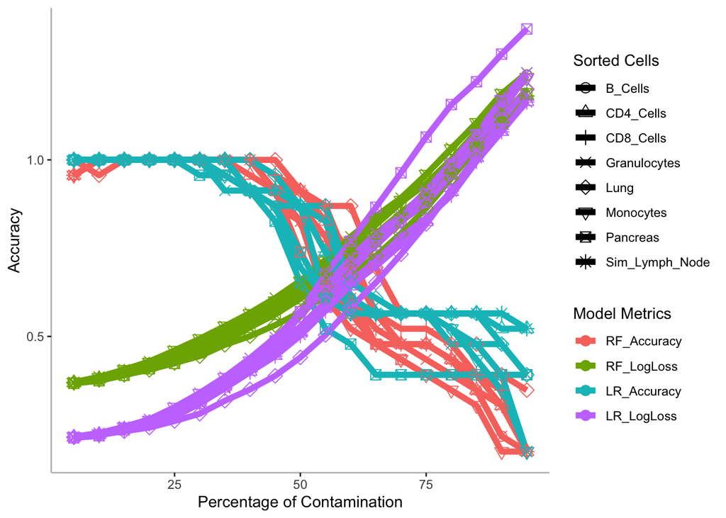

```r
# plot results
Legend<-TRUE
results_longsub<-subset(results_long, OutputType != "RF_AUC" & OutputType!="LR_AUC" & Group!="Perfect_Mix_Cells")

ggplot(data=results_longsub, aes(x=Percentage, y=Output, color=OutputType, shape=Group))+
  geom_line(size=2, show.legend = Legend)+
  geom_point(size=3, show.legend = Legend)+
  scale_shape_manual(values=1:nlevels(as.factor(results_longsub$Output)))+
  theme(
    panel.border = element_blank(),
    panel.grid.major = element_blank(),
    panel.grid.minor = element_blank(),
    panel.background = element_blank(),
    axis.line = element_line(colour = "grey"),
    legend.key=element_blank(),
    legend.background=element_blank())+
  labs(x= "Percentage of Contamination", y="Accuracy", color  = "Model Metrics", linetype = "Model Metrics", shape = "Sorted Cells")
```

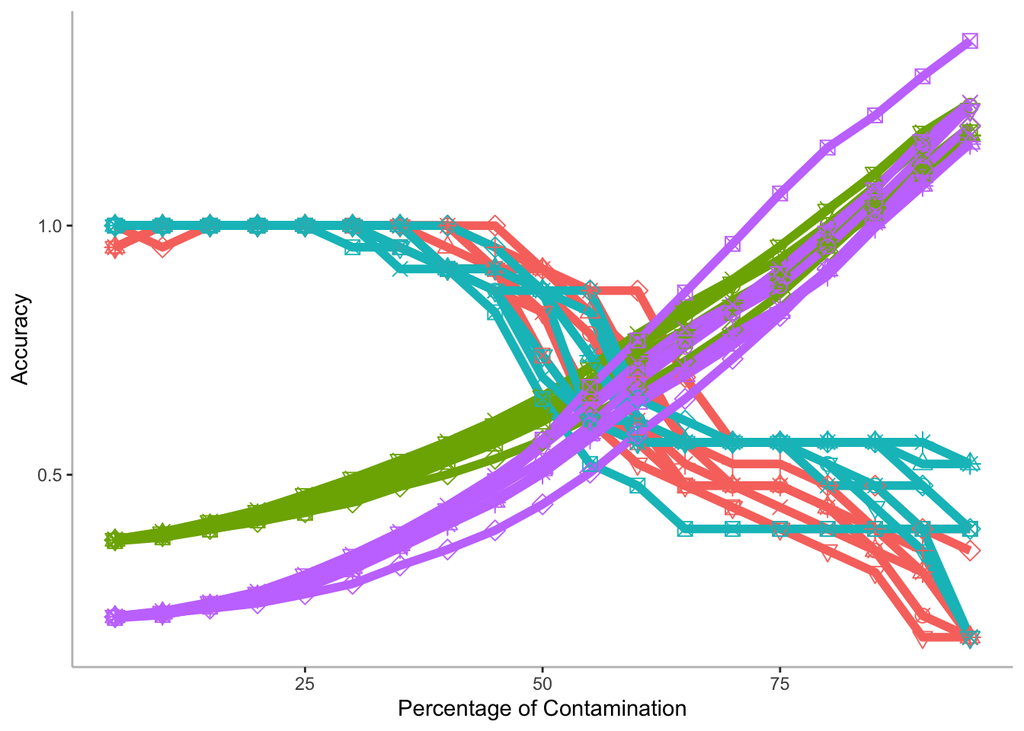

```r
ggsave("Contamination_leg.eps", path = "./05_Contamination/", width = 7.5,
  height = 4,
  units = "in")

# plot results
Legend<-FALSE
results_longsub<-subset(results_long, OutputType != "RF_AUC" & OutputType!="LR_AUC" & Group!="Perfect_Mix_Cells")

ggplot(data=results_longsub, aes(x=Percentage, y=Output, color=OutputType, shape=Group))+
  geom_line(size=2, show.legend = Legend)+
  geom_point(size=3, show.legend = Legend)+
  scale_shape_manual(values=1:nlevels(as.factor(results_longsub$Output)))+
  theme(
    panel.border = element_blank(),
    panel.grid.major = element_blank(),
    panel.grid.minor = element_blank(),
    panel.background = element_blank(),
    axis.line = element_line(colour = "grey"),
    legend.key=element_blank(),
    legend.background=element_blank())+
  labs(x= "Percentage of Contamination", y="Accuracy", color  = "Model Metrics", linetype = "Model Metrics", shape = "Sorted Cells")
```

```r
ggsave("Contamination_noleg.eps", path = "./05_Contamination/", width = 7.5,
  height = 4,
  units = "in")
```

References: (1) Tedla, N., et al. “Phenotypic and functional characterization of lymphocytes derived from normal and HIV-1-infected human lymph nodes.” Clinical and experimental immunology 117.1 (1999): 92. (2) Battaglia, Alessandra, et al. “Lymphocyte populations in human lymph nodes. Alterations in CD4+ CD25+ T regulatory cell phenotype and T‐cell receptor Vβ repertoire.” Immunology 110.3 (2003): 304-312. (3) Stankovic, Branislava, et al. “Immune cell composition in human non-small cell lung cancer.” Frontiers in immunology 9 (2019): 3101. (4) Setiadi, A. Francesca, et al. “Quantitative, architectural analysis of immune cell subsets in tumor-draining lymph nodes from breast cancer patients and healthy lymph nodes.” PLoS One 5.8 (2010).